# 03 - Interactive Viz

```python
#Useful imports
import pandas as pd
import folium
import json
import math
import numpy as np

import seaborn
import matplotlib.pyplot as plt
import branca.colormap as cm
from matplotlib.colors import ListedColormap

%matplotlib inline
```

1 Unemployment rate in Europe

2 Unemployment rate in Switzerland: cantons

3 Unemployment rate in Switzerland: Swiss vs foreign workers

4 Unemployment rate in Switzerland: areas divided by the Röstigraben

## 1 - Unemployment rate in Europe

[source: [eurostat](http://ec.europa.eu/eurostat/data/database)]

By having a look at eurostat, we can find a file that seems perfect following this path :

> Database by theme >> Population and social conditions Labour market >> Employment and unemployment >> LFS series - detailed quarterly survey results (from 1998 onwards) >> Total unemployment - LFS series >> lfsq_urgan.

We manually downloaded the data (as a .tsv file ('tab-separated values'))

```python
data = pd.DataFrame.from_csv('./lfsq_urgan.tsv', sep='\t')
data = data.reset_index()
```

Here is a preview of what the data looks like:

```python
data.head()
```

|  | unit,sex,age,citizen,geo\time | 2017Q2 | 2017Q1 | 2016Q4 | 2016Q3 | 2016Q2 | 2016Q1 | 2015Q4 | 2015Q3 | 2015Q2 | ... | 2000Q2 | 2000Q1 | 1999Q4 | 1999Q3 | 1999Q2 | 1999Q1 | 1998Q4 | 1998Q3 | 1998Q2 | 1998Q1 |
| --- | --- | --- | --- | --- | --- | --- | --- | --- | --- | --- | --- | --- | --- | --- | --- | --- | --- | --- | --- | --- | --- |
| 0 | PC,F,Y15-19,EU15_FOR,AT | : u | : u | : u | : u | : u | : u | : u | : | : | ... | : | : u | : | : | : | : | : | : | : | : |
| 1 | PC,F,Y15-19,EU15_FOR,BE | : u | : bu | : | : u | : | : | : u | : | : | ... | : u | : u | : u | : | : | : b | : | : | : u | : |
| 2 | PC,F,Y15-19,EU15_FOR,BG | : | : | : | : | : | : | : | : | : | ... | : | : | : | : | : | : | : | : | : | : |
| 3 | PC,F,Y15-19,EU15_FOR,CH | 18.5 u | 27.7 u | 16.5 u | 27.3 u | 17.7 u | 10.4 u | 27.1 u | 18.6 u | 21.2 u | ... | : u | : | : | : | : u | : | : | : | : u | : |
| 4 | PC,F,Y15-19,EU15_FOR,CY | : u | : u | : | : u | : u | : u | : | : u | : u | ... | : u | : | : | : | : | : | : | : | : | : |

5 rows × 79 columns

We see that the first column groups multiple features together: 'unit', 'sex', 'age', 'citizen' and 'geo'. Therefore, we split it into multiple columns so that each feature can be handled more easily. We then reorder the columns by moving the new columns to the front of the dataframe, so that reading is easier.

```python
#split the first column into 5 separate columns
data['unit'],data['sex'],data['age'],data['citizen'],data['geo'] = data[data.columns[0]].str.split(',').str

#drop the previous column
data = data.drop(data.columns[0], axis=1)

#reorder the columns
columns = data.columns.tolist()
columns = columns[-5:] + columns[:-5]

data = data[columns]
```

```python
data.head()
```

|  | unit | sex | age | citizen | geo | 2017Q2 | 2017Q1 | 2016Q4 | 2016Q3 | 2016Q2 | ... | 2000Q2 | 2000Q1 | 1999Q4 | 1999Q3 | 1999Q2 | 1999Q1 | 1998Q4 | 1998Q3 | 1998Q2 | 1998Q1 |
| --- | --- | --- | --- | --- | --- | --- | --- | --- | --- | --- | --- | --- | --- | --- | --- | --- | --- | --- | --- | --- | --- |
| 0 | PC | F | Y15-19 | EU15_FOR | AT | : u | : u | : u | : u | : u | ... | : | : u | : | : | : | : | : | : | : | : |
| 1 | PC | F | Y15-19 | EU15_FOR | BE | : u | : bu | : | : u | : | ... | : u | : u | : u | : | : | : b | : | : | : u | : |
| 2 | PC | F | Y15-19 | EU15_FOR | BG | : | : | : | : | : | ... | : | : | : | : | : | : | : | : | : | : |
| 3 | PC | F | Y15-19 | EU15_FOR | CH | 18.5 u | 27.7 u | 16.5 u | 27.3 u | 17.7 u | ... | : u | : | : | : | : u | : | : | : | : u | : |
| 4 | PC | F | Y15-19 | EU15_FOR | CY | : u | : u | : | : u | : u | ... | : u | : | : | : | : | : | : | : | : | : |

5 rows × 83 columns

Next we list all the possible age intervals present in this file:

```python
print(data['age'].unique())
```

```
['Y15-19' 'Y15-24' 'Y15-39' 'Y15-59' 'Y15-64' 'Y15-74' 'Y20-24' 'Y20-64'
 'Y25-29' 'Y25-49' 'Y25-54' 'Y25-59' 'Y25-64' 'Y25-74' 'Y30-34' 'Y35-39'
 'Y40-44' 'Y40-59' 'Y40-64' 'Y45-49' 'Y50-54' 'Y50-59' 'Y50-64' 'Y50-74'
 'Y55-59' 'Y55-64' 'Y60-64' 'Y65-69' 'Y65-74' 'Y70-74']
```

For our analysis, we choose to consider entries with an age interval of 'Y20-64': before 20 years, most people have not worked yet and are not considered as unemployed, and around 64, people start to retire or have already.

When considering the country of citizenship ('citizen'), we will use the entries having the value 'TOTAL'.

```python
print(data['citizen'].unique())
```

```
['EU15_FOR' 'EU27_FOR' 'EU28_FOR' 'FOR' 'NAT' 'NEU15_FOR' 'NEU27_FOR'
 'NEU28_FOR' 'NRP' 'TOTAL']
```

Each entry also specifies whether it applies to 'Female' ('F'), 'Male' ('M') or 'Total' ('T').

```python
print(data['sex'].unique())
```

```
['F' 'M' 'T']
```

We will only consider entries with the 'T' value, which regroups the percentages for both men and women.

Here is a resume of the meaning of each column and the possible values:

- **unit**: the unit of the data,

  > Here, 'PC' indicated the data is a percentage
- **sex**: the sex of the individuals in the considered population

| Code | Description |
| --- | --- |
| F | Females |
| M | Males |
| T | Total |

- **age**: the age of the individuals in the considered population (the ages are grouped in intervals of various size, e.g. Y15-19: from 15 to 19 years):

| Age interval |
| --- |
| Y15-19 Y15-24 Y15-39 Y15-59 Y15-64 Y15-74 |
| Y20-24 Y20-64 |
| Y25-29 Y25-49 Y25-54 Y25-59 Y25-64 Y25-74 |
| Y30-34 |
| Y35-39 |
| Y40-44 Y40-59 Y40-64 |
| Y45-49 |
| Y50-54 Y50-59 Y50-64 Y50-74 |
| Y55-59 Y55-64 |
| Y60-64 |
| Y65-69 Y65-74 |
| Y70-74 |

- **citizen**: the country of citizenship of the individuals on the considered population

| Code | Description |
| --- | --- |
| EU28_FOR | EU28 countries except reporting country |
| EU27_FOR | EU27 countries except reporting country |
| EU15_FOR | EU15 countires except reporting country |
| NEU28_FOR | Non-EU28 countries nor reporting country |
| NEU27_FOR | Non-EU27 countries nor reporting country |
| NEU25_FOR | Non-EU15 countries nor reporting country |
| FOR | Foreign country |
| NAT | Reporting country |
| TOTAL | Total |
| NRP | No response |

- **geo**: the country of residence of the individuals in the considered population

| Code | Description | Code | Description | Code | Description |
| --- | --- | --- | --- | --- | --- |
| EU28 | European Union (28 countries) | DE | Germany | L | Latvia |
| EU27 | European Union (27 countries) | EE | Estoania | MK | Macedonia |
| EU15 | European Union (15 countries) | EL | Greece | MT | Malta |
| EA19 | Euro area (19 countries) | ES | Spain | NL | Netherlands |
| EA18 | Euro area (18 countries) | FI | Finland | NO | Norway |
| EA17 | Euro area (17 countres) | FR | France | PL | Poland |
| AT | Austria | HR | Croatia | PT | Portugal |
| BE | Belgium | HU | Hungary | RO | Romania |
| BG | Bulgaria | IE | Ireland | SE | Sweden |
| CH | Switzerland | IS | Iceland | SI | Slovenia |
| CV | Cyprus | IT | Italy | SK | Slovakia |
| CZ | Czech Republik | LT | Lithuania | TR | Turkey |
| DK | Denmark | LU | Luxembourg | UK | United Kingdom |

- **time**: the year and quadrimester for which the data applies

  > e.g. '2017Q2': the second quarter of the year 2017

We will show on the map only the most recent data, that is, from the second quadrimester of 2017 ('2017Q2').

Next we filter the data by keeping only the entries we are interested in:

```python
datafilter = data[(data['age']=='Y20-64')
                & (data['citizen']=='TOTAL')
                & (data['sex']=='T') ].copy()

#convert to numeric
datafilter.rename(columns = {'2017Q2 ':'2017Q2'}, inplace=True)
datafilter['2017Q2'] = pd.to_numeric(datafilter['2017Q2'],errors='coerce')
# keep not null
datafilter = datafilter[datafilter['2017Q2'].notnull()]
#remove the global data on europe
datafilter = datafilter[~(datafilter['geo'].str.startswith('EU') | datafilter['geo'].str.startswith('EA'))]
```

This is the list of all the country codes in the eurostat statistic:

```python
print(datafilter['geo'].unique().shape)
print(datafilter['geo'].unique())
```

```
(33,)
['AT' 'BE' 'BG' 'CH' 'CY' 'CZ' 'DE' 'DK' 'EE' 'EL' 'ES' 'FI' 'FR' 'HR' 'HU'
 'IE' 'IS' 'IT' 'LT' 'LU' 'LV' 'MK' 'MT' 'NL' 'NO' 'PL' 'PT' 'RO' 'SE' 'SI'
 'SK' 'TR' 'UK']
```

We have a total of 33 countries (i.e. not only european union countries are included). On the other hand, the *topojson/europe.topojson.json* contains the data for 51 countries:

```python
state_geo_path = r'./topojson/europe.topojson.json'
country_list = json.load(open(state_geo_path))['objects']['europe']['geometries']

for f in country_list:
    print(f['id'],'=',f['properties']['NAME'],)
print()
print('Number of countries:', len(country_list))
```

```
AZ = Azerbaijan
AL = Albania
AM = Armenia
BA = Bosnia and Herzegovina
BG = Bulgaria
CY = Cyprus
DK = Denmark
IE = Ireland
EE = Estonia
AT = Austria
CZ = Czech Republic
FI = Finland
FR = France
GE = Georgia
DE = Germany
GR = Greece
HR = Croatia
HU = Hungary
IS = Iceland
IL = Israel
IT = Italy
LV = Latvia
BY = Belarus
LT = Lithuania
SK = Slovakia
LI = Liechtenstein
MK = The former Yugoslav Republic of Macedonia
MT = Malta
BE = Belgium
FO = Faroe Islands
AD = Andorra
LU = Luxembourg
MC = Monaco
ME = Montenegro
NL = Netherlands
NO = Norway
PL = Poland
PT = Portugal
RO = Romania
MD = Republic of Moldova
SI = Slovenia
ES = Spain
SE = Sweden
CH = Switzerland
TR = Turkey
GB = United Kingdom
UA = Ukraine
SM = San Marino
RS = Serbia
VA = Holy See (Vatican City)
RU = Russia

Number of countries: 51
```

The *topojson/europe.topojson.json* overlay uses the international ISO 3166-1 alpha-2 convention. However, there are two countries whose 2-letter european country code differ from this alpha-2 convention: Greece and the United Kingdom, which are mapped to 'EL' and 'UK' instead of 'GR' and 'GB' respectively. We map them to the ISO 3166-1 alpha-2 convention, because this is the one used ini the *topojson/europe.topojson.json*.

note: the european convention uses the native name of the country for assigning the country code, not the english one.

```python
datafilter.loc[datafilter['geo']=='UK', 'geo'] = 'GB'
datafilter.loc[datafilter['geo']=='EL', 'geo'] = 'GR'
```

We do not keep the countries in the json overlay for which we do not have any data from Eurostat (e.g. Azerbaijan, Monaco, Russia, ...), because we do not want them to get displayed on the map.

```python
with open(state_geo_path) as json_data:
    europe_topojson = json.load(json_data)

#access the list of countries in the json
europe_topojson_list = europe_topojson['objects']['europe']['geometries']

#get the country codes in the eurostat data (ISO 3166-1 alpha-2 convention)
european_country_codes = datafilter['geo'].unique()

#filter out the countries whose country code to not appear in the eurostat country codes
non_eurostat_countries = [c for c in europe_topojson_list if (c['id'] not in european_country_codes)]
eurostat_topojson_list = [c for c in europe_topojson_list if c not in non_eurostat_countries]

#assign the updated country list to the new json overlay
eurostat_topojson = europe_topojson
eurostat_topojson['objects']['europe']['geometries'] = eurostat_topojson_list
```

Next we find the quartiles in the unemployment rate in order to estalish a scale of five intervals:

```python
min_unemployment_rate = datafilter['2017Q2'].min()
max_unemployment_rate = datafilter['2017Q2'].max()
print('minimum unemployment rate: {:8.2f} %'.format(min_unemployment_rate))
print('maximum unemployment rate: {:8.2f} %'.format(max_unemployment_rate))
```

```
minimum unemployment rate:     2.60 %
maximum unemployment rate:    22.40 %
```

```python
scale = list( datafilter['2017Q2'].quantile([x * 1/5 for x in range(1, 5)]).values)
scale = [math.floor(min_unemployment_rate)] + scale + [math.ceil(max_unemployment_rate)]
print('scale:', scale)
```

```
scale: [2, 4.3200000000000003, 5.2800000000000002, 7.0199999999999996, 9.5000000000000018, 23]
```

```python
lausanne_coord = [48.519962, 6.633597]
m_europe = folium.Map(location=lausanne_coord, tiles='cartodbpositron', zoom_start=4)

m_europe.choropleth(geo_data=eurostat_topojson,
                    data=datafilter,
                    columns=['geo', '2017Q2'],
                    threshold_scale=scale,
                    key_on='id',
                    topojson='objects.europe',
                    fill_color='YlOrBr', fill_opacity=1, line_opacity=0.2,
                    legend_name='Unemployment rate in european countries (%)')
```

```python
m_europe
```

[interactive chart not shown]

### Observations

We displayed the unemployment rate of the second quarter of 2017. sEurostat define the unemployemnt as follows (Commission Regulation (EC) No 1897/2000 for more detail):

> 1. In accordance with the ILO standards adopted by the 13th and 14th International Conference of Labour Statisticians (ICLS), for the purposes of the Community labour force sample survey, unemployed persons comprise persons aged 15 to 74 who were:
>    - (a) without work during the reference week, i.e. neither had a job nor were at work (for one hour or more) in paid employment or self-employment;
>    - (b) currently available for work, i.e. were available for paid employment or self-employment before the end of the two weeks following the reference week;
>    - (c) actively seeking work, i.e. had taken specific steps in the four week period ending with the reference week to seek paid employment or self-employment or who found a job to start later, i.e. within a period of at most three months

Unfortunately, for built-in colour scales, Folium limits the range to 6 colours. This can be misleading: for instance, the map suggests that Italy, Spain, Grece and Croatia have the same unemployment rate, which is not the case.

```python
datafilter[datafilter['geo'].isin(['GR', 'IT', 'ES', 'HR'])][['2017Q2','geo']]
```

|  | 2017Q2 | geo |
| --- | --- | --- |
| 24649 | 21.1 | GR |
| 24650 | 16.9 | ES |
| 24656 | 10.9 | HR |
| 24660 | 10.9 | IT |

Italy and Croatia have an unemployment rate near the lower limit of the scale (10%), whereas Greece and Spain have a much higher unemployment rate, near the top limit of the scale. Using quartile scale is a practical way to see variations between the different countries, although it may not show in an obvious manner if there are some outliers or not.

In any case, the map shows that the countries of southern europe have the highest unemployment rate.

With this map, Switzerland seems to stand somewhere below the mean of european countries. A quick numerical check confirms this observation:

```python
print('Switzerland\'s unemployment rate: {0:.4f} %'.format(datafilter[datafilter['geo']=='CH']['2017Q2'].values[0]))
print('Average unemployment rate: {0:.4f} %'.format(datafilter['2017Q2'].mean()))
```

```
Switzerland's unemployment rate: 4.5000 %
Average unemployment rate: 7.6061 %
```

## 2 - Unemployment rate in Switzerland: cantons

[source: [amstat](https://www.amstat.ch/v2/index.jsp)]

We first load the data we manually downloaded from the [amstat](https://www.amstat.ch/v2/index.jsp) website:

```python
dataCSV = pd.DataFrame.from_csv('./2_1 Taux de chômage.csv',encoding='utf-16', sep='\t')
```

```python
dataCSV.head()
```

| 2.1 Taux de chômage |
| --- |
| Canton,"Mois","Septembre 2017","Septembre 2017","Septembre 2017","Septembre 2017","Septembre 2017","Total","Total","Total","Total","Total" |
| ,"Mesures","Taux de chômage","Coefficients de variation","Chômeurs inscrits","Demandeurs d'emploi","Demandeurs d'emploi non chômeurs","Taux de chômage","Coefficients de variation","Chômeurs inscrits",… |
| Zurich,,"3.3","A","27'225","34'156","6'931","3.3","A","27'225","34'156","6'931" |
| Berne,,"2.4","A","13'658","18'385","4'727","2.4","A","13'658","18'385","4'727" |
| Lucerne,,"1.7","A","3'885","6'756","2'871","1.7","A","3'885","6'756","2'871" |

As we are only interested in the unemployment rate, we first perform some data cleaning on the dataframe:

```python
data = dataCSV.copy()

#drop the header
data = data.iloc[2:-1]

#keep the cantons
data['canton'] = list(data.index.str.split(",").str)[0]
#keep the unemployment rate ('Taux de chômage') and convert it to a numerical value
data['unemployment rate'] = list(data.index.str.split(",").str)[2]
data['unemployment rate'] = pd.to_numeric(data['unemployment rate'].str.replace('"', ''))

data.reset_index(drop=True,inplace=True)
```

```python
data.head()
```

|  | canton | unemployment rate |
| --- | --- | --- |
| 0 | Zurich | 3.3 |
| 1 | Berne | 2.4 |
| 2 | Lucerne | 1.7 |
| 3 | Uri | 0.6 |
| 4 | Schwyz | 1.7 |

We will use a dictionary mapping the canton code to the canton names used by [amstat](https://www.amstat.ch/v2/index.jsp). This allows use to map each canton's entry to the cantons in the json overlay for Switzerland's topology without having to deal with the translation of canton's names between different languages.

```python
amstat_canton_code_mapping = {'Argovie':'AG',
                              'Appenzell Rhodes-Extérieures':'AR',
                              'Appenzell Rhodes-Intérieures':'AI',
                              'Berne':'BE',
                              'Bâle-Campagne':'BL',
                              'Bâle-Ville':'BS',
                              'Fribourg':'FR',
                              'Genève':'GE',
                              'Glaris':'GL',
                              'Grisons':'GR',
                              'Jura':'JU',
                              'Lucerne':'LU',
                              'Obwald':'OW',
                              'Neuchâtel':'NE',
                              'Nidwald':'NW',
                              'St-Gall':'SG',
                              'Schaffhouse':'SH',
                              'Soleure':'SO',
                              'Schwyz':'SZ',
                              'Thurgovie':'TG',
                              'Tessin':'TI',
                              'Uri':'UR',
                              'Vaud':'VD',
                              'Valais':'VS',
                              'Zoug':'ZG',
                              'Zurich':'ZH'}
```

```python
data['id'] = data['canton'].map(amstat_canton_code_mapping)

#reorder the columns: move the canton code to the front of the dataframe
columns = data.columns.tolist()
columns = columns[-1:] + columns[:-1]
data = data[columns]

data.head()
```

|  | id | canton | unemployment rate |
| --- | --- | --- | --- |
| 0 | ZH | Zurich | 3.3 |
| 1 | BE | Berne | 2.4 |
| 2 | LU | Lucerne | 1.7 |
| 3 | UR | Uri | 0.6 |
| 4 | SZ | Schwyz | 1.7 |

For good measure, we list all cantons of *topojson/ch-cantons.topojson.json* verify there are no missing cantons in either the json or in the dataframe.

note: the cantons are usually listed in the order of precedence given in the federal constitution, which is the order used in Swiss official documents.

```python
state_geo_path = r'./topojson/ch-cantons.topojson.json'
canton_list = json.load(open(state_geo_path))['objects']['cantons']['geometries']

for f in canton_list:
    print(f['id'],'=',f['properties']['name'],)

print()
print('ch-cantons.topojson.json - Number of cantons:', len(canton_list))
print('dataframe - Number of cantons:', len(data['canton']))
```

```
ZH = ZÃ¼rich
BE = Bern/Berne
LU = Luzern
UR = Uri
SZ = Schwyz
OW = Obwalden
NW = Nidwalden
GL = Glarus
ZG = Zug
FR = Fribourg
SO = Solothurn
BS = Basel-Stadt
BL = Basel-Landschaft
SH = Schaffhausen
AR = Appenzell Ausserrhoden
AI = Appenzell Innerrhoden
SG = St. Gallen
GR = GraubÃ¼nden/Grigioni
AG = Aargau
TG = Thurgau
TI = Ticino
VD = Vaud
VS = Valais/Wallis
NE = NeuchÃ¢tel
GE = GenÃ¨ve
JU = Jura

ch-cantons.topojson.json - Number of cantons: 26
dataframe - Number of cantons: 26
```

We can now display the map of Switerland:

```python
#we use the geographical center of Switzerland for centering the map
switzerland_center_coord = [46.801111, 8.226667]
```

```python
m_swiss = folium.Map(location=switzerland_center_coord, tiles='cartodbpositron', zoom_start=7)
m_swiss.choropleth(geo_data=open(state_geo_path), data=data,
             columns=['id', 'unemployment rate'],
             key_on='id',
             topojson='objects.cantons',
             fill_color='YlOrRd', fill_opacity=1, line_opacity=0.2,
             legend_name='Percentage of unemployment in Switzerland per canton (%)')
```

```python
m_swiss
```

[interactive chart not shown]

### Observations

It is in Romandy (also known as the French-speaking Switzerland), that the unemployment rate tends to be the highest.

Now, we will slightly change the way we count unemployed individuals: we will not take into account those which already have a job and are looking for a new one ('Demandeurs d'emploi non chômeurs'), but only those who are looking for a job and have currently none ('Chômeurs inscrits').

note: in the amstat file, 'Chômeurs inscrits' + 'Demandeurs d'emploi non chômeurs' = 'Demandeurs d'emploi'

The [amstat](https://www.amstat.ch/v2/index.jsp) institution defines the unemployment rate as:

> *Nombre de chômeurs inscrits au jour de référence (dernier jour du mois) divisé par le nombre de personnes actives, multiplié par 100. Le nombre des personnes actives est recensé chaque année par l’Office fédéral de la statistique dans le cadre du relevé structurel (recensement de la population). Il s’élève, depuis le 1<sup>er</sup> janvier 2014, à 4'493'249 personnes d’après le pooling de trois ans des données récoltées dans le cadre des relevés structurels de 2012 à 2014. Le nombre des personnes actives utilisé par le SECO comprend aussi les diplomates et fonctionnaires internationaux domiciliés en Suisse.* (from https://www.amstat.ch/v2/definition.jsp?lang=fr)

Registered unemployed individuals ("chômeurs inscrits") are defined as:

> *Personnes annoncées auprès des offices régionaux de placement, qui n'ont pas d'emploi et sont immédiatement disponibles en vue d'un placement. Peu importe qu'elles touchent, ou non, une indemnité de chômage.* (from https://www.amstat.ch/v2/definition.jsp?lang=fr)

It is in these individuals we are interested.

```python
data = dataCSV.copy()
data.index.str.split(",").str[4]
```

```
Index(['"Septembre 2017"', '"Chômeurs inscrits"', '"27'225"', '"13'658"',
       '"3'885"', '"112"', '"1'455"', '"153"', '"248"', '"416"', '"1'543"',
       '"4'466"', '"3'801"', '"3'455"', '"4'082"', '"1'286"', '"523"', '"62"',
       '"6'127"', '"1'166"', '"10'684"', '"3'058"', '"5'202"', '"17'155"',
       '"4'816"', '"4'738"', '"12'234"', '"1'619"', '"133'169"'],
      dtype='object', name='2.1 Taux de chômage')
```

We begin by applying the same data cleaning on the dataframe as before

```python
data = dataCSV.copy()

#drop the header
data = data.iloc[2:-1]

#keep the canton
data['canton'] = list(data.index.str.split(",").str)[0]

data['id'] = data['canton'].map(amstat_canton_code_mapping)
#reorder the columns: move the canton code to the front of the dataframe
columns = data.columns.tolist()
columns = columns[-1:] + columns[:-1]
data = data[columns]
```

Next we add the unemployment rate ('Taux de chômage') and the number of registered unemployed individuals ('Demandeurs d'emploi') to the dataframe

```python
#keep the unemployment rate ('Taux de chômage') and convert it to a numerical value
data['unemployment rate'] = list(data.index.str.split(",").str)[2]
data['unemployment rate'] = pd.to_numeric(data['unemployment rate'].str.replace('"', ''))

#keep the number of registered unemployed individuals ('Chômeurs inscrits') and convert it to a numerical value
data['asking unemployed'] = list(data.index.str.split(",").str)[4]
data['asking unemployed'] = pd.to_numeric(data['asking unemployed'].str.replace('"', '').str.replace('\'', ''))

#keep the number of employed individuals looking for a new job ('Demandeurs d'emploi non chômeurs') and convert it to a numerical value
data['asking employed'] = list(data.index.str.split(",").str)[6]
data['asking employed'] = pd.to_numeric(data['asking employed'].str.replace('"', '').str.replace('\'', ''))

#keep the number of  all individuals looking for a new job ('Demandeurs d'emploi') and convert it to a numerical value
data['asking all'] = list(data.index.str.split(",").str)[5]
data['asking all'] = pd.to_numeric(data['asking all'].str.replace('"', '').str.replace('\'', ''))
```

The registered unemployment rate can then be obtained by dividing the number of registered unemployed individuals ('Chômeurs inscrits') by the number of active individuals, times 100.

```python
#compute the number of individuals in the active population
data['active'] = (data['asking all']/data['unemployment rate']) * 100

#compute the registered unemployment rate
data['asking unemployed rate'] = list(data.index.str.split(",").str)[4]
data['asking unemployed rate'] = pd.to_numeric(data['asking unemployed rate'].str.replace('"', '').str.replace("'",''))/(data['active'])*100

data.reset_index(drop=True,inplace=True)

data.head()
```

|  | id | canton | unemployment rate | asking unemployed | asking employed | asking all | active | asking unemployed rate |
| --- | --- | --- | --- | --- | --- | --- | --- | --- |
| 0 | ZH | Zurich | 3.3 | 27225 | 6931 | 34156 | 1.035030e+06 | 2.630358 |
| 1 | BE | Berne | 2.4 | 13658 | 4727 | 18385 | 7.660417e+05 | 1.782932 |
| 2 | LU | Lucerne | 1.7 | 3885 | 2871 | 6756 | 3.974118e+05 | 0.977575 |
| 3 | UR | Uri | 0.6 | 112 | 145 | 257 | 4.283333e+04 | 0.261479 |
| 4 | SZ | Schwyz | 1.7 | 1455 | 774 | 2229 | 1.311176e+05 | 1.109690 |

```python
#make a copy of this dataframe for Question 4
data_swiss_unemployment_with_distinction = data.copy()
```

We can now display the map

```python
m_swiss = folium.Map(location=switzerland_center_coord, tiles='cartodbpositron', zoom_start=7)
m_swiss.choropleth(geo_data=open(state_geo_path), data=data,
             columns=['id', 'asking unemployed rate'],
             key_on='id',
             topojson='objects.cantons',
             fill_color='YlOrRd', fill_opacity=1, line_opacity=0.2,
             legend_name='Percentage of unemployed people asking for a job in Switzerland per canton (%)')
```

```python
m_swiss
```

[interactive chart not shown]

### Observations

This map and the previous one are not exactly the same, but they are very similar. In all cantons, the "unemployment rate" is now lower (of the order of 0.5% - 2%), since for all active population, less individuals were taken into account (i.e. only the unemployed individuals looking for a job, and not the ones which already have a job). The global trend is still the same though, with Romandy having a higher unemployment rate than the German-speaking part of Switzerland on average.

## 3 - Unemployment rate in Switzerland: Swiss vs foreign workers

[source: [amstat](https://www.amstat.ch/v2/index.jsp)]

Now we repeat the exercise for Switzerland but distinguishing Swiss workers from foreign ones.

> *The Economic Secretary (SECO) releases a monthly report on the state of the employment market. In the latest report (September 2017), it is noted that there is a discrepancy between the unemployment rates for foreign (5.1%) and Swiss (2.2%) workers.*

### 3.1 - Difference in unemployment on two maps

*Show the difference in unemployment rates between the two categories in each canton on a Choropleth map (hint The easy way is to show two separate maps, but can you think of something better ?).*

```python
dataCSV = pd.DataFrame.from_csv('./2_1 Taux de chômage_nat.csv',encoding='utf-16', sep='\t')
dataCSV.head()
```

| 2.1 Taux de chômage |
| --- |
| Canton,"Nationalité","Mois","Septembre 2017","Septembre 2017","Septembre 2017","Total","Total","Total" |
| , ,"Mesures","Taux de chômage","Coefficients de variation","Chômeurs inscrits","Taux de chômage","Coefficients de variation","Chômeurs inscrits" |
| Zurich,"Etrangers",,"5.3","A","12'111","5.3","A","12'111" |
| Zurich,"Suisses",,"2.5","A","15'114","2.5","A","15'114" |
| Berne,"Etrangers",,"5.5","A","4'900","5.5","A","4'900" |

```python
data = dataCSV.copy()
data = data.iloc[2:-1]
```

```python
#drop the header
data = dataCSV.copy()
data = data.iloc[2:-1]

#keep the cantons
data['canton'] = list(data.index.str.split(",").str)[0]

#keep the nationality (i.e. 'swiss' or 'foreigner')
data['nationality'] = list(data.index.str.split(",").str)[1]
data['nationality'] = data['nationality'].str.replace('"', '')
data['nationality'] = data['nationality'].str.replace('Suisses', 'swiss')
data['nationality'] = data['nationality'].str.replace('Etrangers', 'foreigners')

#keep the unemployment rate
data['unemployment rate'] = list(data.index.str.split(",").str)[3]
data['unemployment rate'] = pd.to_numeric(data['unemployment rate'].str.replace('"', ''))

data.reset_index(drop=True,inplace=True)
data['id'] = data['canton'].map(amstat_canton_code_mapping)
#reorder the columns: move the canton code to the front of the dataframe
columns = data.columns.tolist()
columns = columns[-1:] + columns[:-1]
data = data[columns]

data.head()
```

|  | id | canton | nationality | unemployment rate |
| --- | --- | --- | --- | --- |
| 0 | ZH | Zurich | foreigners | 5.3 |
| 1 | ZH | Zurich | swiss | 2.5 |
| 2 | BE | Berne | foreigners | 5.5 |
| 3 | BE | Berne | swiss | 1.8 |
| 4 | LU | Lucerne | foreigners | 3.9 |

In this dataframe, the nationality is stored as a separate column, which duplicates the entry per canton. However, we would like to have a single entry per canton: we will therefore reshape the dataframe:

```python
#pivot the table to get both rates in the same row
data_concat = data.pivot(index='canton', columns = 'nationality', values=('unemployment rate'))

#reset the index
data_concat.reset_index(inplace=True)

#rename the columns
data_concat.columns = ['canton', 'foreigners', 'swiss']

#add the 2-letters code of the canton as id
data_concat['id'] = data_concat['canton'].map(amstat_canton_code_mapping)
#reorder the columns: move the canton code to the front of the dataframe
columns = data_concat.columns.tolist()
columns = columns[-1:] + columns[:-1]
data_concat = data_concat[columns]

data_concat.head()
```

|  | id | canton | foreigners | swiss |
| --- | --- | --- | --- | --- |
| 0 | AR | Appenzell Rhodes-Extérieures | 3.4 | 1.4 |
| 1 | AI | Appenzell Rhodes-Intérieures | 2.0 | 0.5 |
| 2 | AG | Argovie | 5.6 | 2.1 |
| 3 | BE | Berne | 5.5 | 1.8 |
| 4 | BL | Bâle-Campagne | 4.8 | 2.2 |

```python
threshold_scale = np.linspace(data_concat['foreigners'].min(),
                              data_concat['foreigners'].max(), 8, dtype=int).tolist()
```

```python
m_swiss_foreigners = folium.Map(location=switzerland_center_coord, tiles='cartodbpositron', zoom_start=7)
m_swiss_foreigners.choropleth(geo_data=open(state_geo_path), data=data_concat,
             columns=['id', 'foreigners'],
             key_on='id',
             topojson='objects.cantons',
             fill_color='YlOrRd', fill_opacity=1, line_opacity=0.2,
             legend_name='Percentage of foreigners unemployment in Switzerland per canton (%)',
            threshold_scale=None)
```

```python
m_swiss_swiss = folium.Map(location=switzerland_center_coord, tiles='cartodbpositron', zoom_start=7)
m_swiss_swiss.choropleth(geo_data=open(state_geo_path), data=data_concat,
             columns=['id', 'swiss'],
             key_on='id',
             topojson='objects.cantons',
             fill_color='YlOrRd', fill_opacity=1, line_opacity=0.2,
             legend_name='Percentage of swiss unemployment in Switzerland per canton (%)',
                        threshold_scale=None)
```

Below is the map per canton of the unemployment rate among foreigners in Switzerland

```python
m_swiss_foreigners
```

[interactive chart not shown]

And here is the map per canton of the unemployment rate among Swiss in Switzerland

note: although the colour scale is the same, the absolute scale of this map is less than the half of the precedent (!)

```python
m_swiss_swiss
```

[interactive chart not shown]

### Observations

As a global trend, we see that the unemployment rate for both Swiss and foreigners is still prevalent in Romandy.

On average though, the unemployment rate among foreigners is much higher than among the Swiss, and this for every single canton. This suggests there is a positive bias toward the Swiss and a negative one toward foreigners when it comes to hiring.

Half of the foreigners are Italian (~15.6%), Germans (~14.9%), Portuguese (~13.2) or French (~6.3%). Italians tend to live in the canton of Ticino, Portuguese in Romandy and in the east of the canton of Grisons and French mostly in Romandy - cantons which are marked with colours of the right-side of the scale (except for the canton of Grisons). If there are more foreigners living in these parts of Switzerland, we could also expect the unemployment rate of foreigners to be higher than in regions with fewer of them.

The trend is less visible for the German population however, which mostly lives in the German-speaking part of Switzerland. In fact, for the German-speaking part of Switzerland, the difference in unemployment rate between foreigners and Swiss may be also due to foreigners tending to not be fluent enough in German or Swiss German, thus lowering their chance of finding a job recruted in this region. In general though, this is not a problem for Germans working in Switzerland.

(statistics taken from https://www.sem.admin.ch/sem/fr/home/aktuell/news/2017/2017-07-17.html#moreinfos-tab-0)

### 3.2 - Difference in unemployment on one map

#### Approach 1: bivariate choropleth map try #1

We will first try to create a map which displays both the foreigners and Swiss unemployment rates by superimposing two colour scales.

```python
data_difference = data_concat.copy()
data_difference.head()
```

|  | id | canton | foreigners | swiss |
| --- | --- | --- | --- | --- |
| 0 | AR | Appenzell Rhodes-Extérieures | 3.4 | 1.4 |
| 1 | AI | Appenzell Rhodes-Intérieures | 2.0 | 0.5 |
| 2 | AG | Argovie | 5.6 | 2.1 |
| 3 | BE | Berne | 5.5 | 1.8 |
| 4 | BL | Bâle-Campagne | 4.8 | 2.2 |

We find the quartiles for both the foreigners unemployment rate and the Swiss unemployment rate in order to establish a scale for the two populations.

```python
scale_swiss = list(data_difference['swiss'].quantile([x * 1/5 for x in range(1, 5)]).values)
scale_swiss = [math.floor(data_difference['swiss'].min())] + scale_swiss + [math.ceil(data_difference['swiss'].max())]

scale_foreigners = list(data_difference['foreigners'].quantile([x * 1/5 for x in range(1, 5)]).values)
scale_foreigners = [math.floor(data_difference['foreigners'].min())] + scale_foreigners + [math.ceil(data_difference['foreigners'].max())]
```

The following map has now two different colour scales, which are supposed to be superimposed in some meaningful way:

- If a canton has a dominant purple colour, then the Swiss unemployment rate is here at its largest, and the foreigners unemployment rate at the lowest.
- Inversely, if a canton has a dominant blue colour, then the foreigners unemployment rate is here at its largest, and the Swiss unemployment rate at its lowest.
- If the the dominant colour is some shade of violet - that is, a mix of purple and blue - then this means the foreigners and Swiss unemployment rate are similar, and the higher the darker the purple

```python
map_swiss_foreigners_difference = folium.Map(location=switzerland_center_coord, tiles='cartodbpositron', zoom_start=7)
map_swiss_foreigners_difference.choropleth(geo_data=open(state_geo_path), data=data_difference,
             columns=['id', 'swiss'],
             key_on='id',
             topojson='objects.cantons',
             fill_color='PuRd', fill_opacity=0.9, line_opacity=0.2,
             threshold_scale=scale_swiss,
             legend_name='Unemployment rate for Swiss (%)',
             highlight=True)

map_swiss_foreigners_difference.choropleth(geo_data=open(state_geo_path), data=data_difference,
             columns=['id', 'foreigners'],
             key_on='id',
             topojson='objects.cantons',
             fill_color='PuBu', fill_opacity=0.6, line_opacity=0.2,
             threshold_scale=scale_foreigners,
             legend_name='Unemployment rate for foreigners (%)',
             highlight=True)

map_swiss_foreigners_difference
```

[interactive chart not shown]

We can see there is indeed some trend similar to the one observed on the previous maps. However, this is not an optimal way of representing the difference between foreigners and Swiss unemployment rate, as the opacity of one colour (*fill_opacity*) can be made arbitrarily small or large with respect to the other, this way completely changing the aspect of the map.

We still kept this map for the sake of showing our approach.

#### Approach 2: bivariate choropleth map try #2

Next we will try to create a bivariate choropleth map without actually mixing the colours, but by assigning to each canton the colour from a matrix of colour, which only symbolizes the mixing of colours.

For this, we find the terciles for both the foreigners unemployment rate and the Swiss unemployment rate, as the matrix we will use is going to be a $3 \times 3$ matrix.

```python
tercile_swiss_1 = list(data_difference['swiss'].sort_values())[int(np.floor(len(data_difference['swiss'])/3))]
tercile_swiss_2 = list(data_difference['swiss'].sort_values())[int(np.floor(len(data_difference['swiss'])*2/3))]

tercile_foreigners_1 = list(data_difference['foreigners'].sort_values())[int(np.floor(len(data_difference['foreigners'])/3))]
tercile_foreigners_2 = list(data_difference['foreigners'].sort_values())[int(np.floor(len(data_difference['foreigners'])*2/3))]

print('swiss:', tercile_swiss_1, tercile_swiss_2)
print('foreigners:', tercile_foreigners_1, tercile_foreigners_2)
```

```
swiss: 1.4 2.2
foreigners: 3.9 5.0
```

We then manually map each canton to a value of the matrix, depending on its foreigners unemployment rate and Swiss unemployment rate.

```python
def non_linear_scale(df):

    if(df['swiss'] < tercile_swiss_1):
        if(df['foreigners'] < tercile_foreigners_1):
            return 1
        elif(tercile_foreigners_1 <= df['foreigners'] and df['foreigners'] < tercile_foreigners_2):
            return 2
        else:
            return 3
    elif(tercile_swiss_1 <= df['swiss'] < tercile_swiss_2):
        if(df['foreigners'] < tercile_foreigners_1):
            return 4
        elif(tercile_foreigners_1 <= df['foreigners'] and df['foreigners'] < tercile_foreigners_2):
            return 5
        else:
            return 6
    else:
        if(df['foreigners'] < tercile_foreigners_1):
            return 7
        elif(tercile_foreigners_1 <= df['foreigners'] and df['foreigners'] < tercile_foreigners_2):
            return 8
        else:
            return 9
```

```python
data_difference['combined'] = data_difference.apply(non_linear_scale, axis=1)
data_difference.head()
```

|  | id | canton | foreigners | swiss | combined |
| --- | --- | --- | --- | --- | --- |
| 0 | AR | Appenzell Rhodes-Extérieures | 3.4 | 1.4 | 4 |
| 1 | AI | Appenzell Rhodes-Intérieures | 2.0 | 0.5 | 1 |
| 2 | AG | Argovie | 5.6 | 2.1 | 6 |
| 3 | BE | Berne | 5.5 | 1.8 | 6 |
| 4 | BL | Bâle-Campagne | 4.8 | 2.2 | 8 |

Below are some possible colour grids for plotting bivariate choropleth maps

```python
grid_1 = ['#dddddd', '#7bb3d1', '#016eae',
          '#dd7c8a', '#8d6c8f', '#4a4779',
          '#cc0024', '#8a274a', '#4b264d']
#http://tolomaps.tumblr.com/post/131671267233/creating-a-bivariate-choropleth-color-scheme
grid_2 = ['#e8e8e8', '#e4d9ac', '#c8b35a',
          '#cbb8d7', '#c8ada0', '#af8e53',
          '#9972af', '#976b82', '#804d36']
grid_3 = ['#e8e8e8', '#e4acac', '#c85a5a',
          '#b0d5df', '#ad9ea5', '#985356',
          '#64acbe', '#627f8c', '#574249']
#http://www.joshuastevens.net/cartography/make-a-bivariate-choropleth-map/
```

We will use the following colour matrix, with the horizontal axis indicating the foreigners unemployment rate, and the vertical axis indicating the Swiss unemployment rate

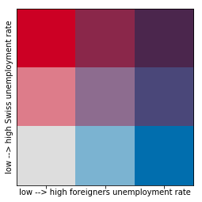

```python
matrix = [[7,8,9],[4,5,6],[1,2,3]]
plt.matshow(matrix, cmap=ListedColormap(grid_1))
plt.xlabel('low --> high foreigners unemployment rate')
plt.ylabel('low --> high Swiss unemployment rate')
plt.tick_params(
    axis='both',
    which='both',
    top='off',
    left='off',
    labeltop='off',
    labelleft='off')

plt.show()
```

```python
colormap_3 = cm.StepColormap(
    grid_1,
    vmin=0, vmax=9,
    index=[0, 1, 2, 3, 4, 5, 6, 7, 8],
    caption='bivariate_like'
)

colormap_3.caption = 'Unemployment rate'

unemployment = data_difference.set_index('id')['combined']

m = folium.Map(location=switzerland_center_coord, tiles='cartodbpositron', zoom_start=7)

folium.TopoJson(
    open(state_geo_path),
    'objects.cantons',
    style_function=lambda feature: {
        'fillColor': colormap_3(unemployment[feature['id']]),
        'color': 'black',
        'weight': 1,
        'dashArray': '5, 5',
        'fillOpacity': 1.0
    }
).add_to(m)

m
```

[interactive chart not shown]

The colours on this map are now less arbitrary than on the one in the first approach, even though they still depend on the split values for both rates.

We observe that none of the two extremes (i.e. low foreigners unemployment rate/high Swiss unemployment rate and high foreigners unemployment rate/low Swiss unemployment rate) are present on the map. This suggest that, although it is present, the discrepancy between both populations could be worse.

We could also try to set the splitting points for the foreigners unemployment rate to the same splitting points as for the Swiss unemployment rate, in order to be able to compare the rates directly.

```python
tercile_foreigners_1 = tercile_swiss_1
tercile_foreigners_2 = tercile_swiss_2
```

In that case, the map changes significantly.

```python
data_difference['combined'] = data_difference.apply(non_linear_scale, axis=1)
```

```python
unemployment = data_difference.set_index('id')['combined']

m = folium.Map(location=switzerland_center_coord, tiles='cartodbpositron', zoom_start=7)

folium.TopoJson(
    open(state_geo_path),
    'objects.cantons',
    style_function=lambda feature: {
        'fillColor': colormap_3(unemployment[feature['id']]),
        'color': 'black',
        'weight': 1,
        'dashArray': '5, 5',
        'fillOpacity': 1.0
    }
).add_to(m)

m
```

[interactive chart not shown]

Now, the foreigners unemployment rate is in almost all cantons considered to be high, except in the canton of Uri and in the canton of Appenzell Innerrhoden (light blue), where it is medium. The unemployment rate is considered to be at the highest for both Swiss and foreigners in the same cantons as before.

In cantons such as the canton of Grison, the canton of Schwyz, the canton of Nidwalden of the canton of Obwalden, the trend for foreigners is completely inverted. The previous map indicated the foreigners unemployment rates were relatively low, but now that these rates are directly compared to the Swiss unemployment rates, they are considered to be high.

No cantons appears in the purple shades either, since the foreigners unemployment rate is always greater than the Swiss unemployment rate.

#### Approach 3: another way to see it ...

A rapid check shows that the swiss rate is always smaller than the foreigners one.

So we can substract the first one to the later one.

```python
canton_centres = {'AR':([47.448522,9.554672],[47.412291,9.453049]),
                  'AI':([47.330446,9.450302],[47.282024,9.376144]),
                  'AG':([47.478232,8.250046],[47.415079,8.144302]),
                  'BE':([46.972756,7.605972],[46.952137,7.493362]),
                  'BL':([47.458737,7.877884],[47.416008,7.761154]),
                  'BS':([47.591346,7.677383],[47.57004,7.57576]),
                    'FR':([46.780314,7.183685],[46.659805, 7.029877]),
                    'GE':([46.239702, 6.238861], [46.180781, 6.027374]),
                    'GL':([47.032695,9.0905],[46.945575,9.047928]),
                    'GR':([46.773731,9.864349],[46.734214,9.488068]),
                    'JU':([47.368594,7.335434],[47.344406,7.100601]),
                    'LU':([47.153303,8.212967],[47.083215,8.068771]),
                    'NE':([47.022398,6.892548],[46.971819,6.648102]),
                    'NW':([46.94745,8.482132],[46.890232,8.399734]),
                    'OW':([46.888355,8.228073],[46.819798,8.141556]),
                    'SH':([47.743017,8.631134],[47.715306,8.507538]),
                    'SZ':([47.070122,8.826141],[47.002734,8.680573]),
                    'SO':([47.309965,7.68631],[47.240084,7.541428]),
                    'SG':([47.182246,9.414597],[47.100045,9.301987]),
                    'TI':([46.392411,8.896179],[46.327965,8.731384]),
                    'TG':([47.61357, 9.194183],[47.561701,9.004669]),
                    'UR':([46.860191,8.765717],[46.77185,8.581696]),
                    'VS':([46.236853,7.45697],[46.183634,7.325134]),
                    'VD': ([46.686189,6.626129], [46.633408, 6.510773]),
                    'ZG':([47.150501,8.603668],[47.148634,8.526764]),
                    'ZH':([47.455951, 8.740997],[47.359293,8.559723])
                 }
```

```python
data_concat['difference'] = data_concat.foreigners - data_concat.swiss
```

```python
m_swiss_diff = folium.Map(location=switzerland_center_coord, tiles='cartodbpositron', zoom_start=8)
m_swiss_diff.choropleth(geo_data=open(state_geo_path), data=data_concat,
             columns=['id', 'difference'],
             key_on='id',
             topojson='objects.cantons',
             fill_color='YlOrRd', fill_opacity=1, line_opacity=0.2,
             legend_name='Percentage of swiss unemployment in Switzerland per canton (%)',
                        threshold_scale=None)

label = ['foreigners', 'swiss']
col = ['green', 'blue']

# For each canton, add 2 circles with rate :
for key in canton_centres:
    s = " Vive la raclette !" if key == 'VS' else ''
    # e takes {1,2} as value
    for e, loc in enumerate(canton_centres[key]):
        rate = (data_difference.loc[data_difference['id']==key][label[e]]).values[0]
        folium.CircleMarker(
            location=loc,
            radius = np.sqrt(rate*100/math.pi), #the area of the circle is proportionnal to the rate
            fill=True,
            popup= key + " :\n" + label[e].capitalize() + " unemployment rate : "
            + str(rate) + '% ' + s, # See the rate when clicking on the circle
            weight=1, color=col[e]
        ).add_to(m_swiss_diff)
```

```python
m_swiss_diff
```

[interactive chart not shown]

Click on circles to get the precise rate of unemployment.

- Green : Foreigners
- Blue : Swiss

### Observations

Apparently, the most significant differences are present in cantons :

- Jura, Neuchâtel, Bern and Argovie

We could maybe link the high difference in Jura (9% vs 3.6%) to the high ratio of french people coming to work in switzerland in this area. However, this is quiet the same case in Geneva, and we have a low difference between them. Another hypothesis would be that most of the labour market in Jura is horlogery, which is quiet a specific market.

### 3.3 - Differences between age groups

```python
dataCSV = pd.DataFrame.from_csv('./unemployment_rate_per_canton_nationality_age_group.csv',encoding='utf-16', sep='\t')
dataCSV.head()
```

| 1.1 Chômeurs et demandeurs d'emploi selon divers critères |
| --- |
| Canton,"Nationalité","Classes d'âge 15-24, 25-49, 50 ans et plus",,"Mois","Septembre 2017" |
| , , ,,"Mesures","Chômeurs inscrits" |
| Zurich,"Etrangers","1","15-24 ans",,"1'015" |
| Zurich,"Etrangers","2","25-49 ans",,"8'846" |
| Zurich,"Etrangers","3","50 ans et plus",,"2'250" |

It again requires a bit of work to import the data from the csv file in a clean and nice pandas dataframe. We will:

- drop the header
- remove any kind of quotation marks
- drop the rows indicating the 'Total' number of unemployed individuals
- replace entries written in french by an english equivalent
- add a column indicating the canton code

```python
data = dataCSV.copy()

#drop the header
data = data.iloc[2:-1]

#keep the canton
data['canton'] = list(data.index.str.split(",").str)[0]

#keep the nationality, but drop the 'Total' rows
data['nationality'] = list(data.index.str.split(",").str)[1]
data['nationality'] = data['nationality'].str.replace('"', '')
data['nationality'] = data['nationality'].str.replace('Suisses', 'swiss')
data['nationality'] = data['nationality'].str.replace('Etrangers', 'foreigners')
data = data[data['nationality'] != 'Total']

#keep the age group, but drop the 'Yotal' rows
data['age group'] = list(data.index.str.split(",").str)[2]
data['age group'] = data['age group'].str.replace('"', '')
data = data[data['age group'] != 'Total']
data['age group'] = pd.to_numeric(data['age group'])

#keep th number of unemplyed individuals
data['number of unemployed'] = list(data.index.str.split(",").str)[5]
data['number of unemployed'] = data['number of unemployed'].str.replace('"', '')
data['number of unemployed'] = data['number of unemployed'].str.replace('\'', '')
data['number of unemployed'] = pd.to_numeric(data['number of unemployed'])

data.reset_index(drop=True,inplace=True)

data['id'] = data['canton'].map(amstat_canton_code_mapping)
data.head(10)
```

|  | canton | nationality | age group | number of unemployed | id |
| --- | --- | --- | --- | --- | --- |
| 0 | Zurich | foreigners | 1 | 1015 | ZH |
| 1 | Zurich | foreigners | 2 | 8846 | ZH |
| 2 | Zurich | foreigners | 3 | 2250 | ZH |
| 3 | Zurich | swiss | 1 | 2405 | ZH |
| 4 | Zurich | swiss | 2 | 8207 | ZH |
| 5 | Zurich | swiss | 3 | 4502 | ZH |
| 6 | Berne | foreigners | 1 | 597 | BE |
| 7 | Berne | foreigners | 2 | 3316 | BE |
| 8 | Berne | foreigners | 3 | 987 | BE |
| 9 | Berne | swiss | 1 | 1406 | BE |

The age groups mapping is

- 1: 15-24 years old
- 2: 25-49 years old
- 3: >50 years old,

but for convenience, we will keep the integer representation 1, 2 and 3 in the dataframe.

In order to create a bar plot displaying the number of unemployed individuals per canton, nationality and age group, we split the previous dataframe into two dataframes: one regrouping the entries about Swiss individuals, the other the entries about foreigners.

```python
table_swiss = pd.pivot_table(data, values='number of unemployed', index=['canton', 'nationality'], columns=['age group'])
table_swiss = table_swiss.xs('swiss', axis=0, level=1, drop_level=False)
table_swiss.head()
```

| canton | age group nationality | 1 | 2 | 3 |
| --- | --- | --- | --- | --- |
| Appenzell Rhodes-Extérieures | swiss | 44 | 151 | 149 |
| Appenzell Rhodes-Intérieures | swiss | 10 | 14 | 15 |
| Argovie | swiss | 958 | 2792 | 1962 |
| Berne | swiss | 1406 | 4457 | 2895 |
| Bâle-Campagne | swiss | 359 | 1270 | 857 |

```python
table_foreigners = pd.pivot_table(data, values='number of unemployed', index=['canton', 'nationality'], columns=['age group'])
table_foreigners = table_foreigners.xs('foreigners', axis=0, level=1, drop_level=False)
table_foreigners.head()
```

| canton | age group nationality | 1 | 2 | 3 |
| --- | --- | --- | --- | --- |
| Appenzell Rhodes-Extérieures | foreigners | 21 | 108 | 50 |
| Appenzell Rhodes-Intérieures | foreigners | 6 | 10 | 7 |
| Argovie | foreigners | 597 | 3270 | 1105 |
| Berne | foreigners | 597 | 3316 | 987 |
| Bâle-Campagne | foreigners | 165 | 1089 | 342 |

```python
def plot_clustered_stacked(df_all, title, labels):
    """Given a list of dataframes, with identical columns and index, create a clustered stacked bar plot.
labels is a list of the names of the dataframe, used for the legend
title is a string for the title of the plot
"""

    n_df = len(df_all)
    n_col = len(df_all[0].columns)
    n_ind = len(df_all[0].index)

    ax = plt.subplot(111)

    #plot each dataframe
    for df in df_all:
        ax = df.plot(kind='bar',
                      linewidth=1.,
                      edgecolor='#e0e0e0',
                      color=['#a6cee3', '#1f78b4', '#b2df8a'],
                      stacked=True,
                      ax=ax,
                      legend=False,
                      grid=False,
                      figsize=(18,8),
                      )

    #position the bars
    H="/"
    h,l = ax.get_legend_handles_labels()
    for i in range(0, n_df * n_col, n_col):
        for j, pa in enumerate(h[i:i+n_col]):
            for rect in pa.patches:
                rect.set_x(rect.get_x() + 1 / float(n_df + 1) * i / float(n_col))
                rect.set_width(1 / float(n_df + 1))
                rect.set_hatch(H * int(i / n_col))


    ax.set_xticks((np.arange(0, 2 * n_ind, 2) + 1 / float(n_df + 1)) / 2.)
    ax.set_xticklabels(df.index, rotation = 90)

    ax.set_xlabel('canton')
    ax.set_ylabel('number of unemployed')
    ax.set_title(title)

    n=[]
    for i in range(n_df):
        n.append(ax.bar(0, 0, color="gray", hatch=H * i))


    #add the legend
    legend_1 = ax.legend(h[:n_col], l[:n_col], loc=[1.01, 0.5])
    if labels is not None:
        legend_2 = plt.legend(n, labels, loc=[1.01, 0.1])
    ax.add_artist(legend_1)

    return ax

#thank you https://stackoverflow.com/questions/22787209/how-to-have-clusters-of-stacked-bars-with-python-pandas
```

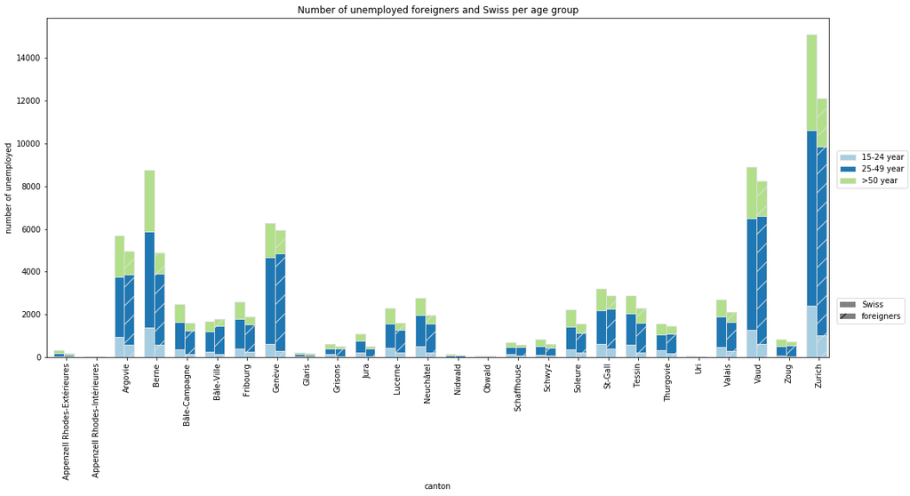

```python
column_names = ['15-24 year', '25-49 year', '>50 year']

df_swiss = pd.DataFrame(table_swiss.values,
                   index=sorted(data['canton'].unique()),
                   columns=column_names)

df_foreigners = pd.DataFrame(table_foreigners.values,
                   index=sorted(data['canton'].unique()),
                   columns=column_names)

plot_clustered_stacked([df_swiss, df_foreigners],
                       'Number of unemployed foreigners and Swiss per age group',
                       ['Swiss', 'foreigners']);
```

### Observations

This bar plot shows the number of unemployed foreigners and Swiss per age group and per canton. These are absolute numbers, and we see that, although the unemployment rate is higher among the foreign population, the number of unemployed foreigners is in most cantons actually lower than the number of unemployed Swiss.

In overall, the proportion of unemployed foreigners or Swiss for the different age groups is similar across all cantons: most unemployed individuals are between 25 and 49 years old, followed by the individuals more than 50 years old. The minority of unemployed individuals is between 15 and 24 years old.

## 4 - Unemployment rate in Switzerland: areas divided by the Röstigraben

[source: [amstat](https://www.amstat.ch/v2/index.jsp)]

We retrieve the data stored previously, and give it a shorter name

```python
data = data_swiss_unemployment_with_distinction
data.head()
```

|  | id | canton | unemployment rate | asking unemployed | asking employed | asking all | active | asking unemployed rate |
| --- | --- | --- | --- | --- | --- | --- | --- | --- |
| 0 | ZH | Zurich | 3.3 | 27225 | 6931 | 34156 | 1.035030e+06 | 2.630358 |
| 1 | BE | Berne | 2.4 | 13658 | 4727 | 18385 | 7.660417e+05 | 1.782932 |
| 2 | LU | Lucerne | 1.7 | 3885 | 2871 | 6756 | 3.974118e+05 | 0.977575 |
| 3 | UR | Uri | 0.6 | 112 | 145 | 257 | 4.283333e+04 | 0.261479 |
| 4 | SZ | Schwyz | 1.7 | 1455 | 774 | 2229 | 1.311176e+05 | 1.109690 |

Next, we sort the cantons according to the language: we make one group out of French-speaking cantons, and another one out of German-, Italian- and Romansh-speaking cantons.

```python
romandy_cantons = ['FR','GE', 'JU', 'NE', 'VD', 'VS']
roesti_cantons = ['AG', 'AR', 'AI', 'BE', 'BL', 'BS', 'GL', 'GR', 'LU', 'OW',
                  'NW', 'SG', 'SH', 'SO', 'SZ', 'TG', 'TI', 'UR', 'ZG', 'ZH']
```

In the same way, we also compute the total number of active individuals, as it will be used to compute the unemployment rate.

```python
romandy_asking_total = data[data['id'].isin(romandy_cantons)]['asking all'].sum()
romandy_active_total = data[data['id'].isin(romandy_cantons)]['active'].sum()

roesti_asking_total = data[data['id'].isin(roesti_cantons)]['asking all'].sum()
roesti_active_total = data[data['id'].isin(roesti_cantons)]['active'].sum()
```

For both parts of Switzerland, the unemployment rate can then be obtained by dividing the total number of unemployed individuals by the total number of active individuals.

```python
romandy_asking_rate = romandy_asking_total/romandy_active_total * 100
roesti_asking_rate = roesti_asking_total/roesti_active_total * 100

print('Unemployed rate in the French-speaking part of Switzerland: {0:.4f} %'.format(romandy_asking_rate))
print('Unemployed rate in the German-speaking part of Switzerland: {0:.4f} %'.format(roesti_asking_rate))
```

```
Unemployed rate in the French-speaking part of Switzerland: 3.9796 %
Unemployed rate in the German-speaking part of Switzerland: 2.5037 %
```

These values confirm what we previously observed on the maps: the unemployment rate is in overall higher in the French-speaking part of Switzerland than in the German-speaking part of Switzerland.